# Branch, Bound, & Kill

April 30, 2015

## While you're waiting . . .

48 male bank supervisors were asked to assume the role of the personnel director of a bank and were given a personnel file to judge whether the person should be promoted to a branch manager position. The files given to the participants were identical, except that half of them indicated the candidate was male and the other half indicated the candidate was female. These files were randomly assigned to the supervisiors. For each supervisor we recorded the gender associated with the assigned file and the promotion decision.

|  | promoted | not promoted |
| --- | --- | --- |
| male | 18 | 6 |
| female | 14 | 10 |

**Is this data consistent with the claim that females are unfairly discriminated against in promotion decisions? What statistical method would you use to make that determination?**

## Branch, Bound, & Kill

## Learning a function

- Where is the function high? Low?
- Steep? Flat?
- How many modes?

\[ f(x) = 18x - 3x^2 \\ f'(x) = 18 - 6x \\ f''(x) = -6 \]

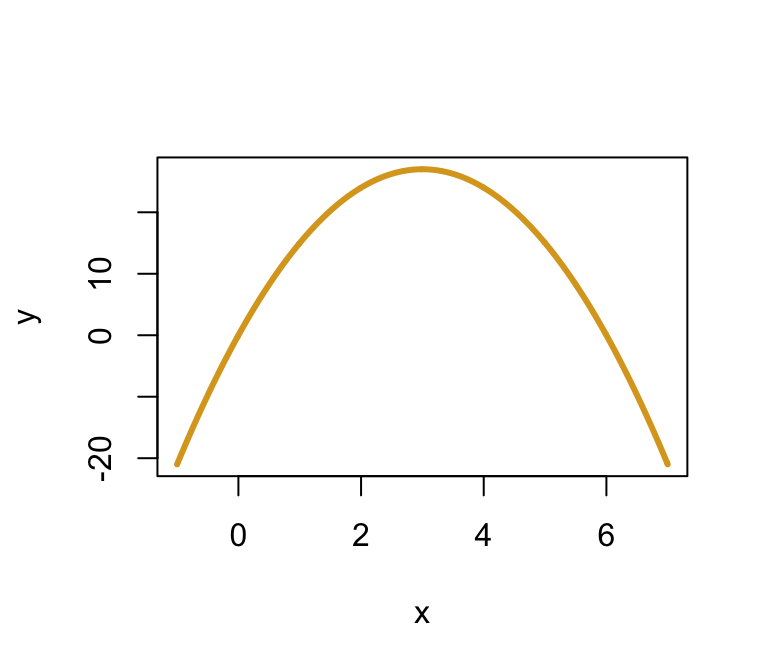

## Learning a function without Calculus

- Evaluate \(f(x)\) at any point \(x\).
- Bound \(f(x)\) on any interval of \(x\).

Learn by iterating over:

1. **Bound**
2. **Kill**
3. **Branch**

## Bound

[figure not shown]

## Bound

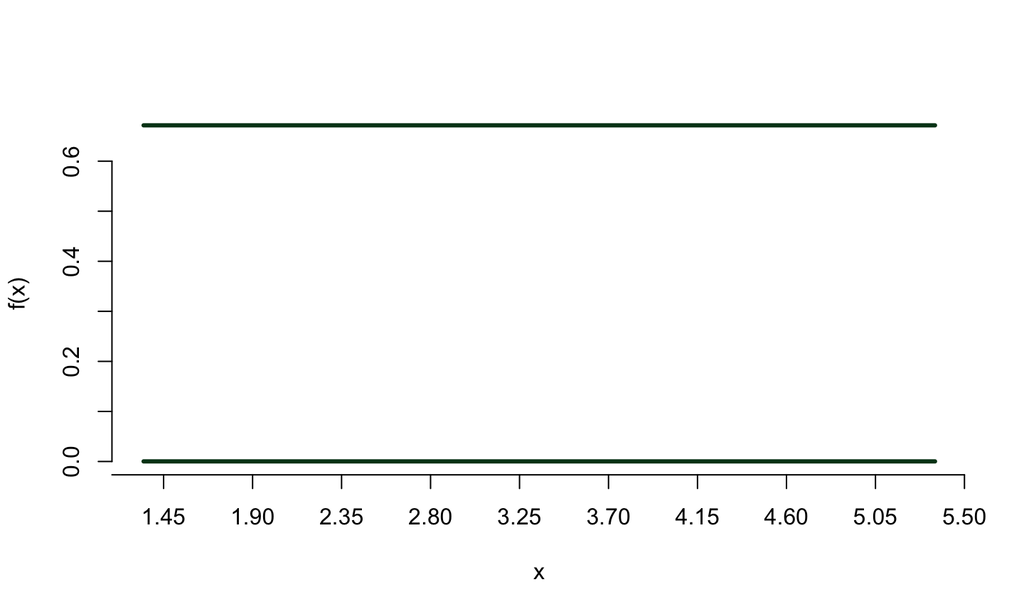

## Kill?

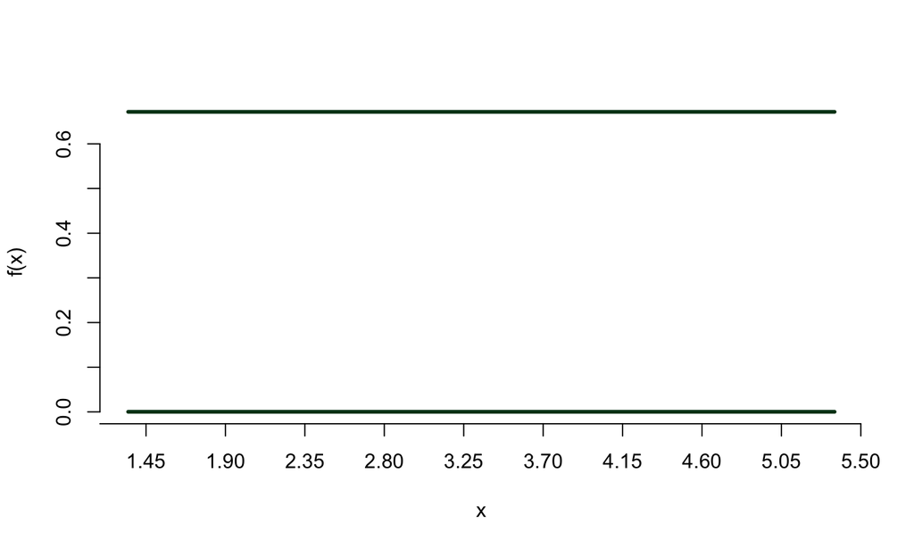

## Kill?

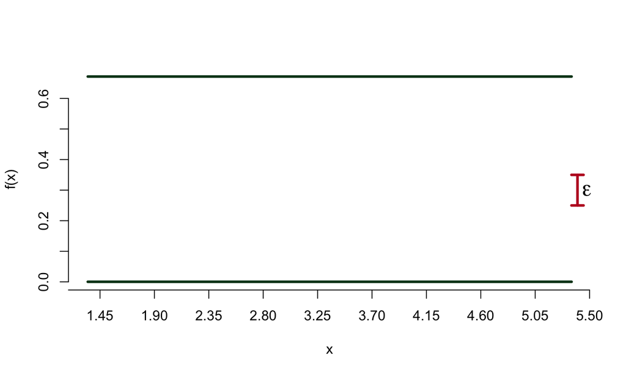

## Branch

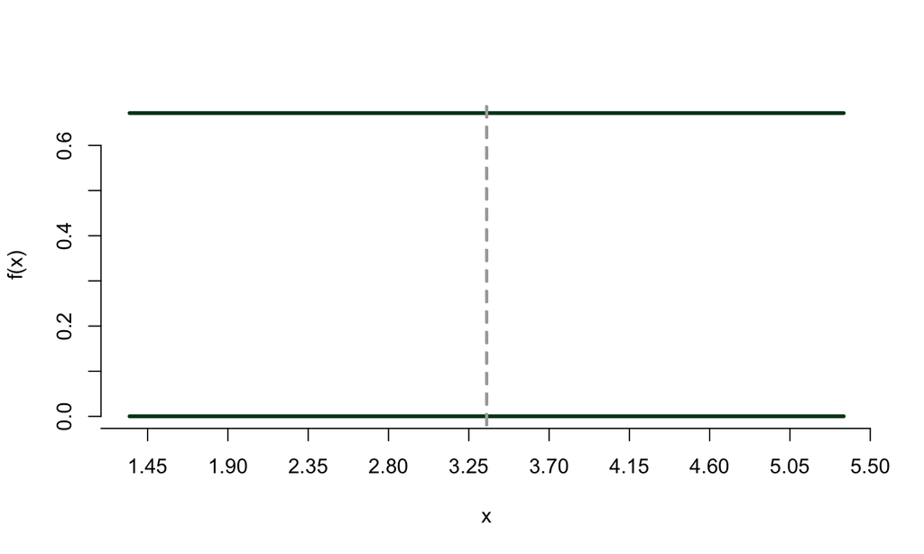

## Bound

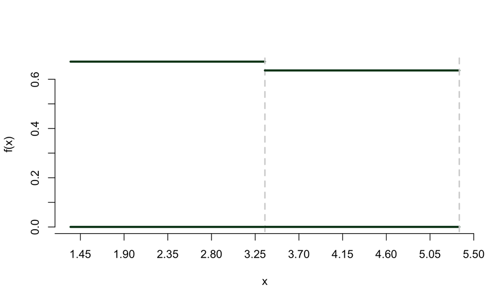

## An Algorithm

To evaluate \(f\) arbitrarily well everywhere within \(B\),

1. Specify \(\epsilon\).
2. For every active bin \(b\)
- calculate \(U^b - L^b\)
- if \(U^b - L^b < \epsilon\), kill \(b\)
- else branch \(b\) into two \(b\)s and repeat (2).

## The Likelihood Function

## While you're waiting . . .

48 male bank supervisors were asked to assume the role of the personnel director of a bank and were given a personnel file to judge whether the person should be promoted to a branch manager position. The files given to the participants were identical, except that half of them indicated the candidate was male and the other half indicated the candidate was female. These files were randomly assigned to the supervisiors. For each supervisor we recorded the gender associated with the assigned file and the promotion decision.

|  | promoted | not promoted |
| --- | --- | --- |
| male | 18 | 6 |
| female | 14 | 10 |

**Is this data consistent with the claim that females are unfairly discriminated against in promotion decisions? What statistical method would you use to make that determination?**

## A model for promotion

|  | promoted | not promoted | p(promoted) |
| --- | --- | --- | --- |
| male | 18 | 6 | 18/24 = .75 |
| female | 14 | 10 | 14/24 = .58 |

Suppose:

1. Each decision was independent.
2. All males were promoted with the same probability \(p_{M}\).
3. All females were promoted with the same probability \(p_{F}\).

\[ Y \sim \textrm{binomial}(n = 24, p = p_{M}) \\ X \sim \textrm{binomial}(n = 24, p = p_{F}) \]

## From Probability to Likelihood

\[ P(\color{red}{y}, \color{red}{x} | n, p_M, p_F) = {n \choose \color{red}{y}} p_M^\color{red}{y} (1 - p_M)^{n-\color{red}{y}} {n \choose \color{red}{x}} p_F^\color{red}{x} (1 - p_F)^{n-\color{red}{x}} \]

vs.

\[ L(\color{red}{p_M}, \color{red}{p_F} | n, y, x) = {n \choose y} \color{red}{p_M}^y (1 - \color{red}{p_M})^{n-y} {n \choose x} \color{red}{p_F}^x (1 - \color{red}{p_F})^{n-x} \]

## The Likelihood Function

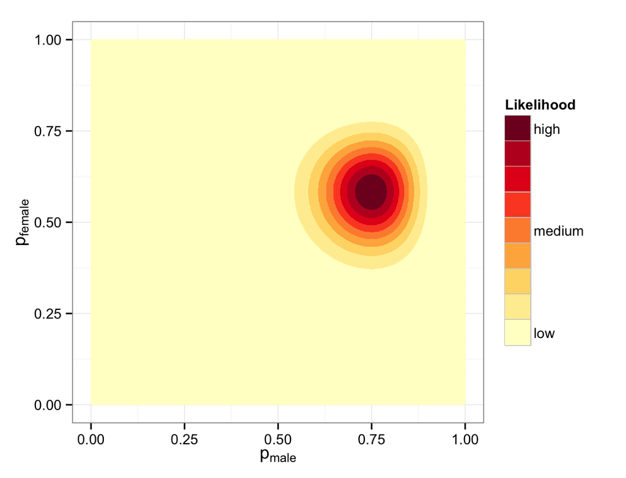

## The Likelihood Function

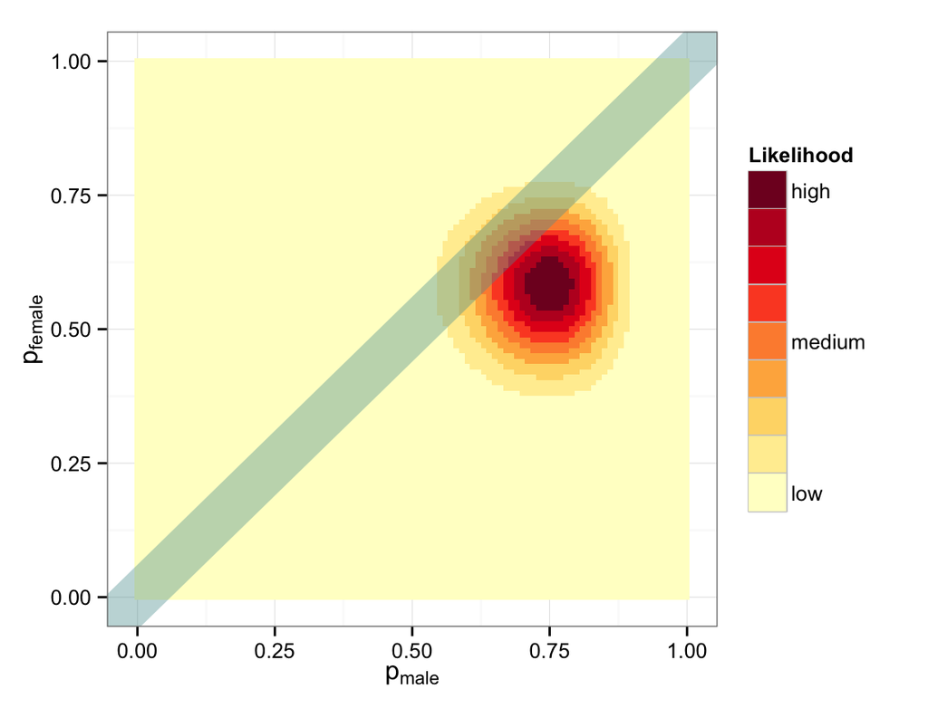

## Likelihood Function, more data

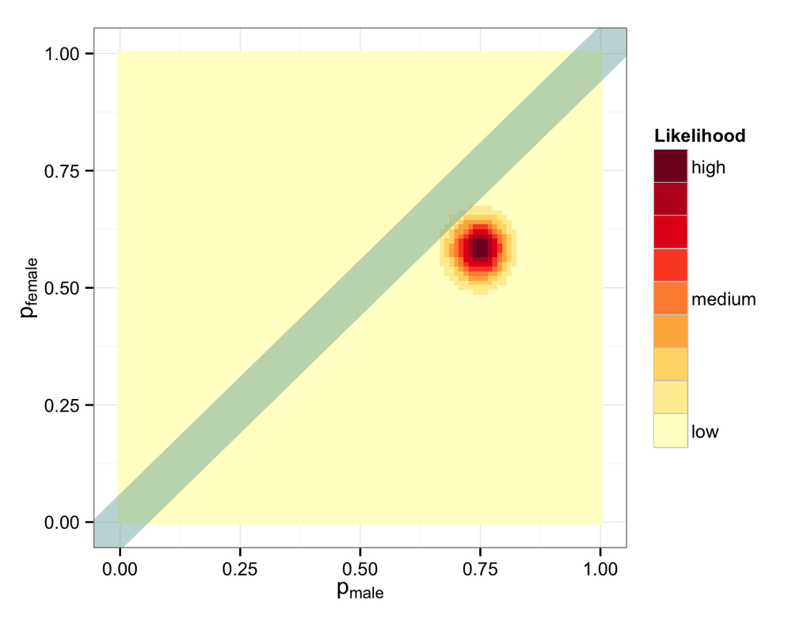

## Likelihood Function, even more data

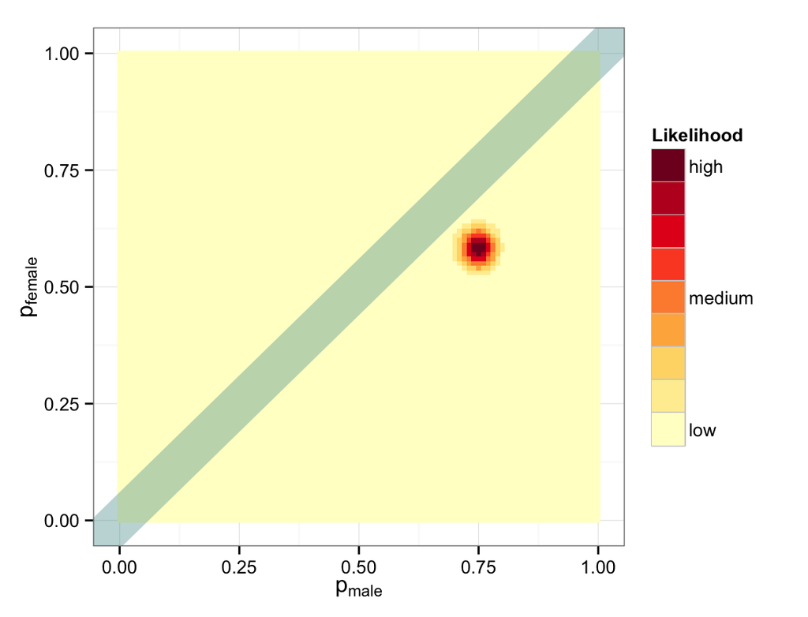

## Learning the Likelihood

## Technique 1: Hill Climbers

[figure not shown]

## Technique 2: Gridded Evaluation

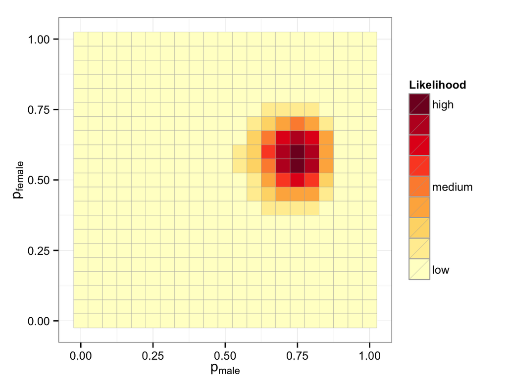

## Branch, Bound, & Kill the Likelihood

A method to evaluate the likelihood or posterior for a linear mixed model in order to

1. **Profile** the shape of the function for sensible inference
2. **Estimate** parameters

while being sure that we're not missing the global optimum.

**How to calculate bounds?**

## Linear Mixed Models

\[ y = X \beta + Z u + \epsilon \]

- \(y, X, Z\): data
- \(\beta, u\): fixed and random effects

\[ \epsilon \sim \textrm{N}(0, R); \quad u \sim \textrm{N}(0, G) \]

The Restricted Log Likelihood:

\[ f (\color{red}{\sigma^2_e}, \color{red}{\sigma^2_s}) \propto \sum_{j=1}^m \left[ c_j \log (a_j \color{red}{\sigma^2_s} + b_j \color{red}{\sigma^2_e} ) + \frac{d_j}{a_j \color{red}{\sigma^2_s} + b_j \color{red}{\sigma^2_e}} \right] \]

\[ \{a_j, b_j, c_j, d_j\} > 0 \]

## Exploiting the linear structure

\[ c_j \log(\textrm{linear term}) + \frac{d_j}{\textrm{linear term}} \]

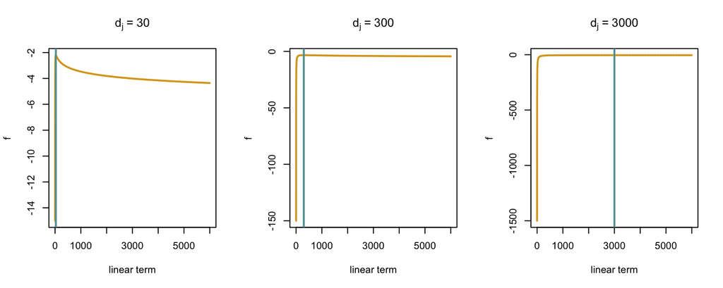

## Exploiting the linear structure

\[ f(\sigma^2_e, \sigma^2_s) \propto \sum_j \left[ c_j \log (a_j \sigma^2_s + b_j \sigma^2_e ) + \frac{d_j}{(a_j \sigma^2_s + b_j \sigma^2_e)} \right] \]

Taking derivatives:

\[ \frac{\partial f(\sigma^2_e, \sigma^2_s)}{\partial \sigma^2_e} \propto \sum_j \frac{a_j (a_j c_j \sigma^2_s + b_j c_j \sigma^2_e - d_j)}{(a_j \sigma^2_s + b_j \sigma^2_e)^2} \]

\[ \begin{aligned} 0 &= a_j c_j \sigma^2_s + b_j c_j \sigma^2_e - d_j \\ \\ \sigma^2_s &= \frac{d_j}{a_j c_j} - \frac{b_j}{a_j}\sigma^2_e \end{aligned} \]

## Contribution of one term

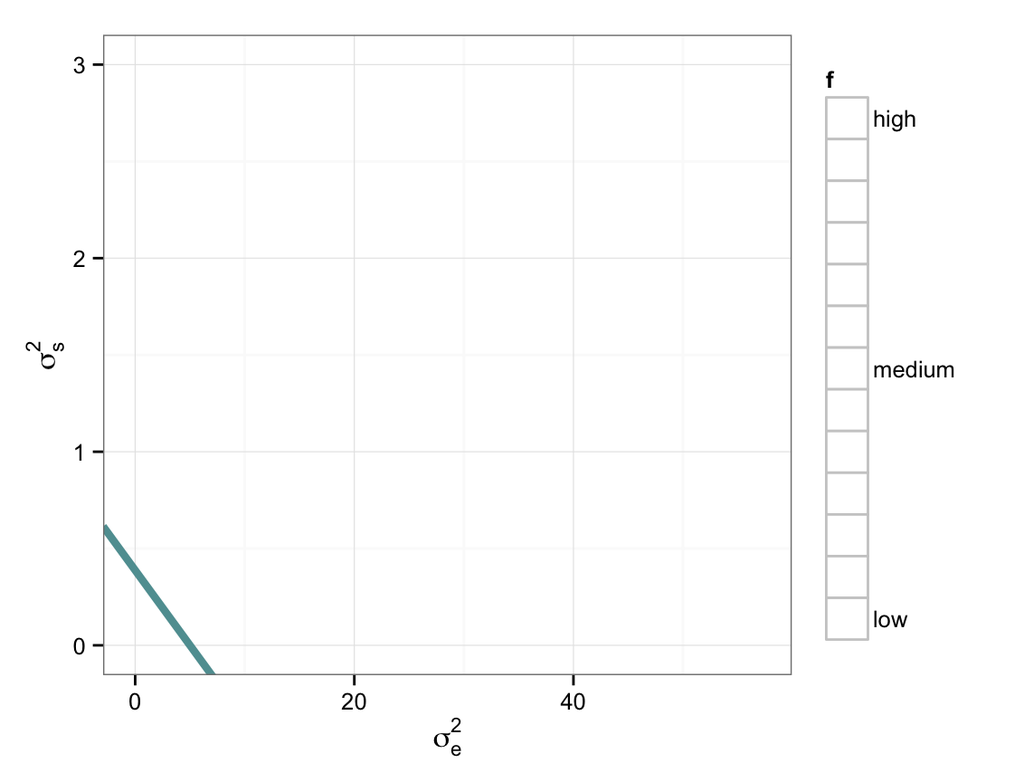

\(a_j = 12.9; \quad b_j = 1; \quad c_j = 1; \quad d_j = 5\)

\(f\) is maxed along \(\sigma^2_s = \frac{d_j}{a_j c_j} - \frac{b_j}{a_j}\sigma^2_e\)

## Contribution of one term

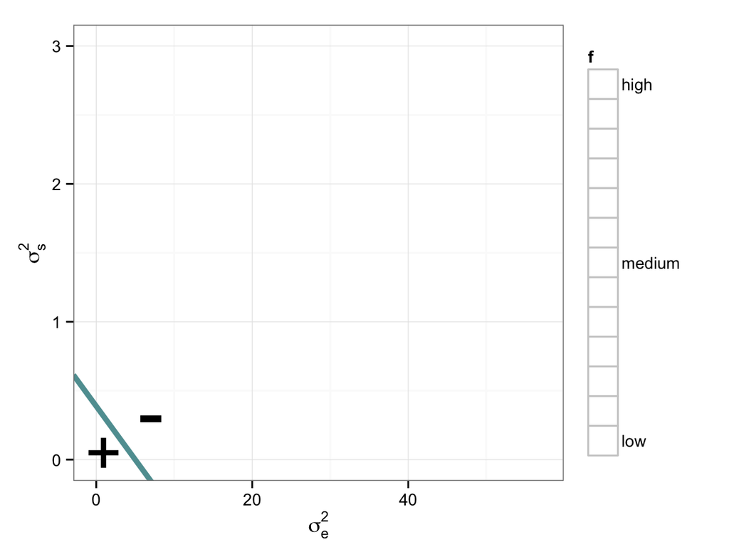

## Contribution of one term

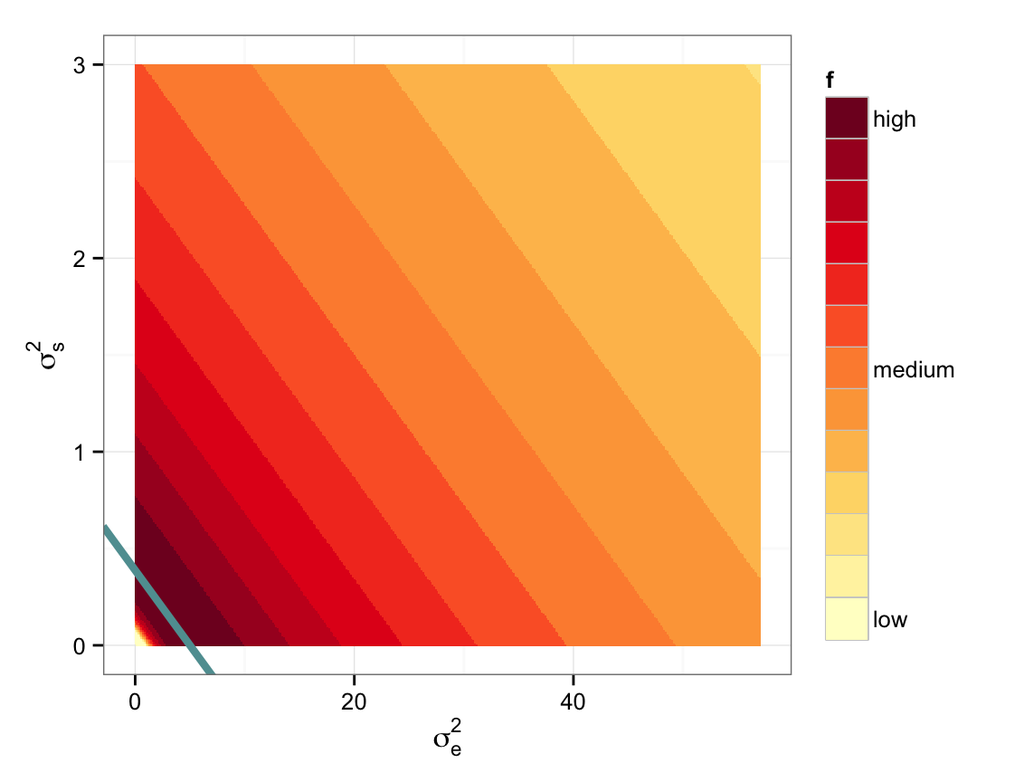

## Box above line

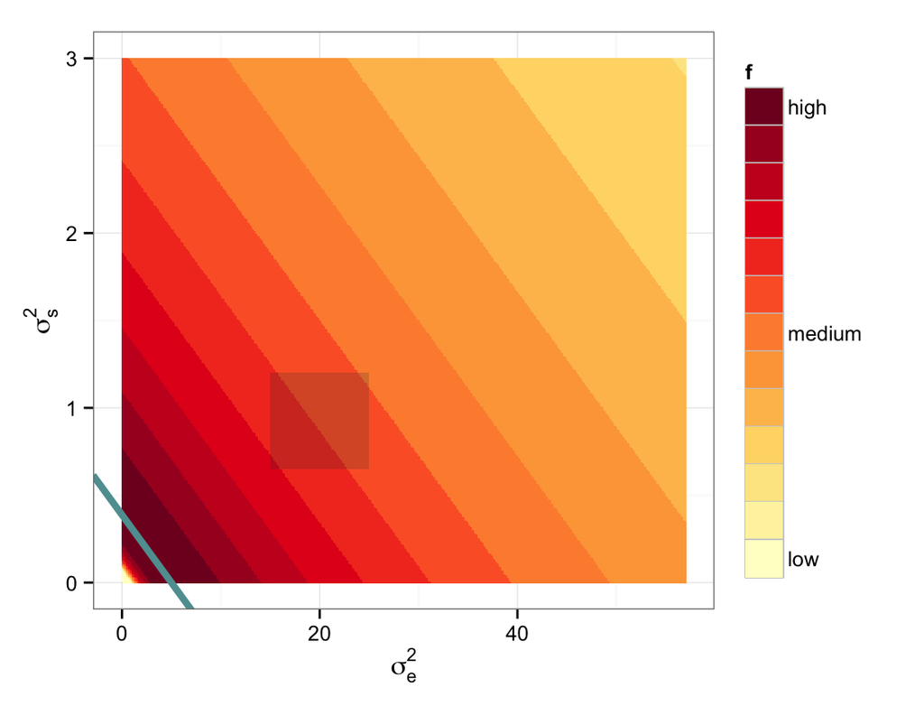

## Box above line

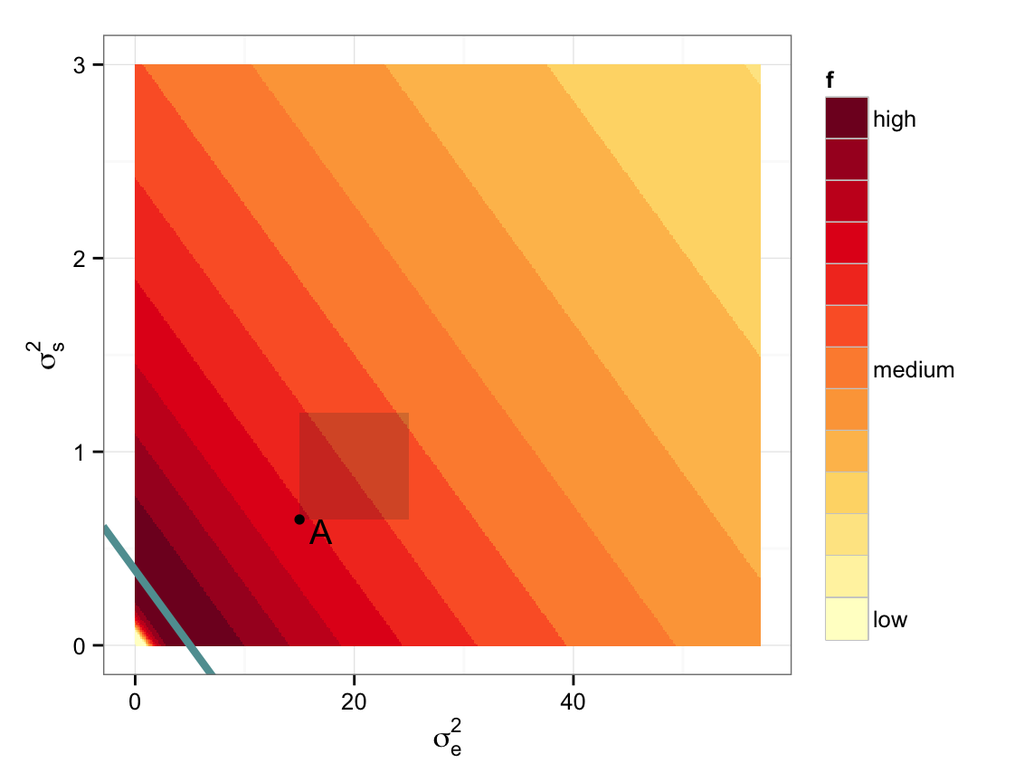

## Box above line

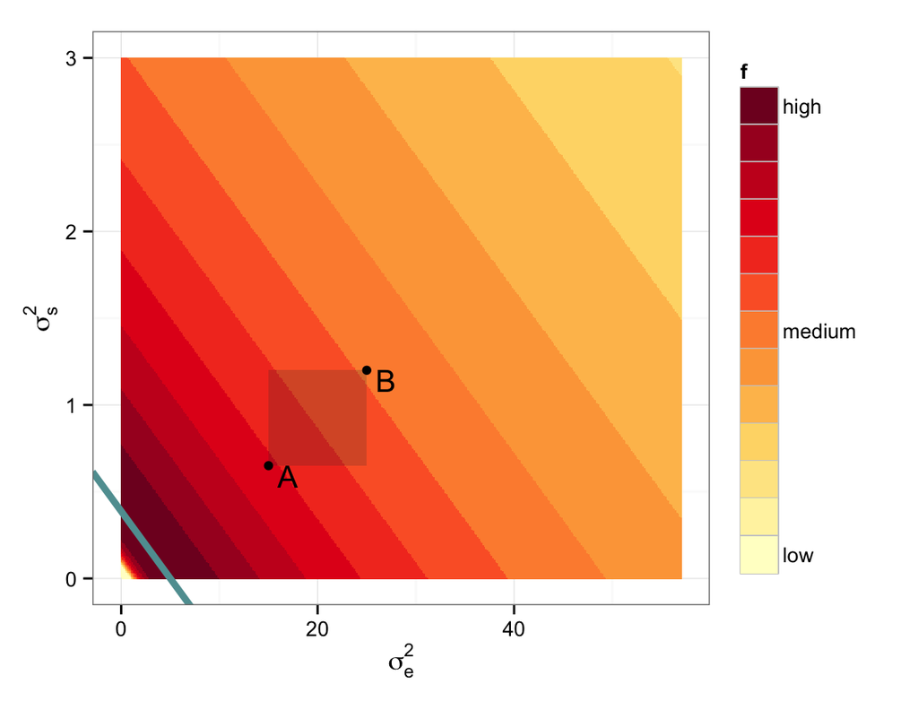

Bounds on \(f\) in box \(b_a: \left(f(B), f(A) \right)\)

## Box straddles line

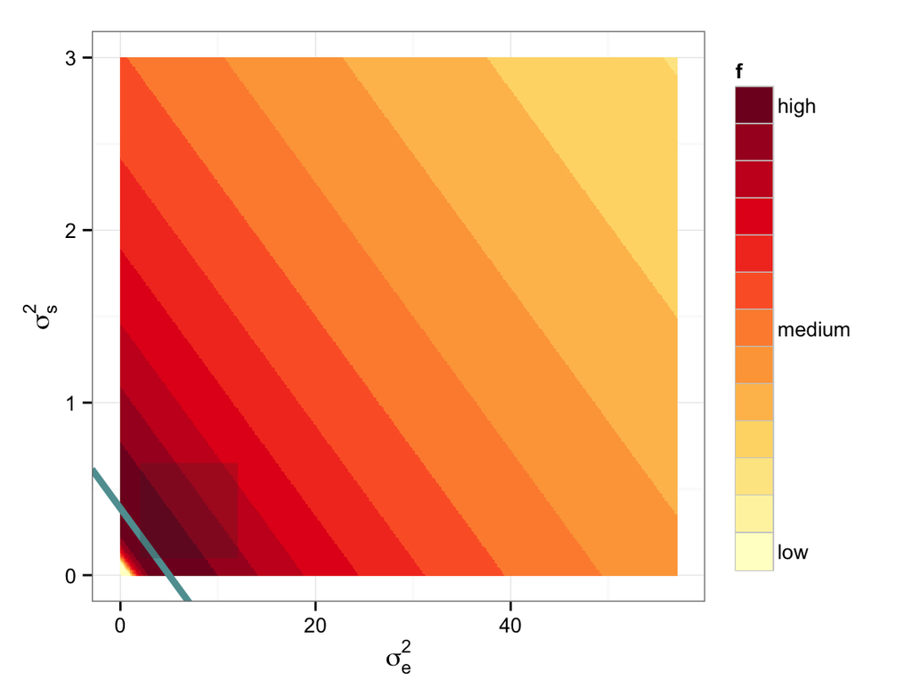

## Box straddles line

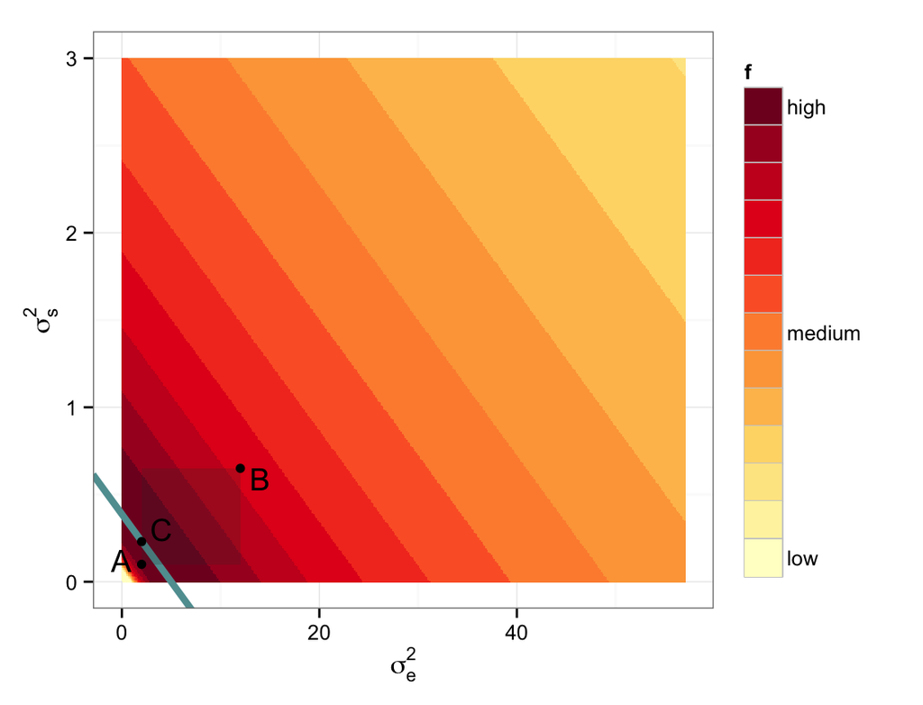

Bounds on \(f\) in box \(b_s: \left(min\left(f(A), f(B)\right), f(C) \right)\)

## Branch for more precision

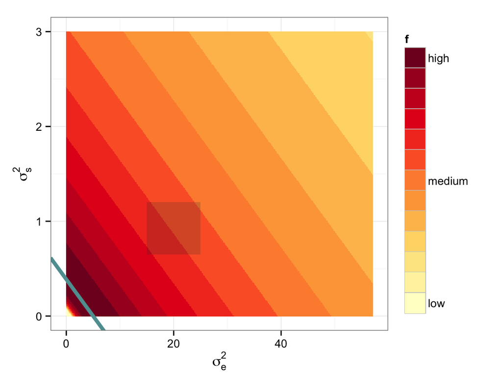

## Branch for more precision

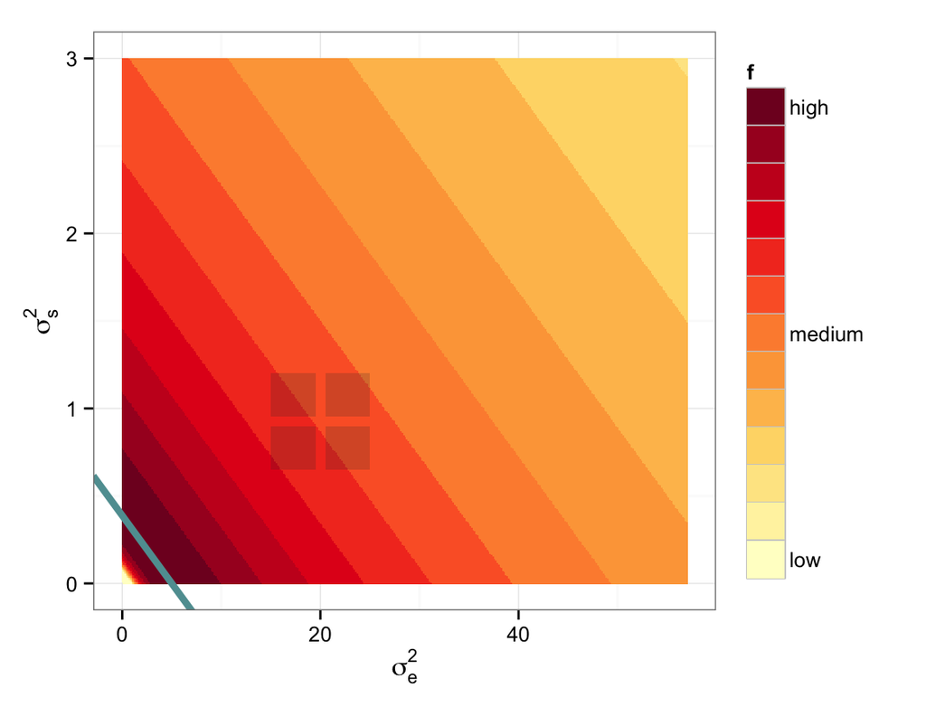

## Branch for more precision

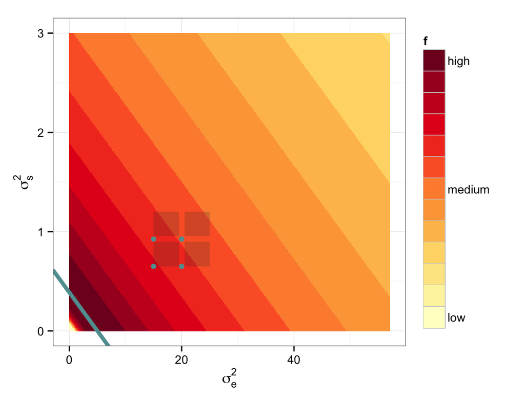

## Branch for more precision

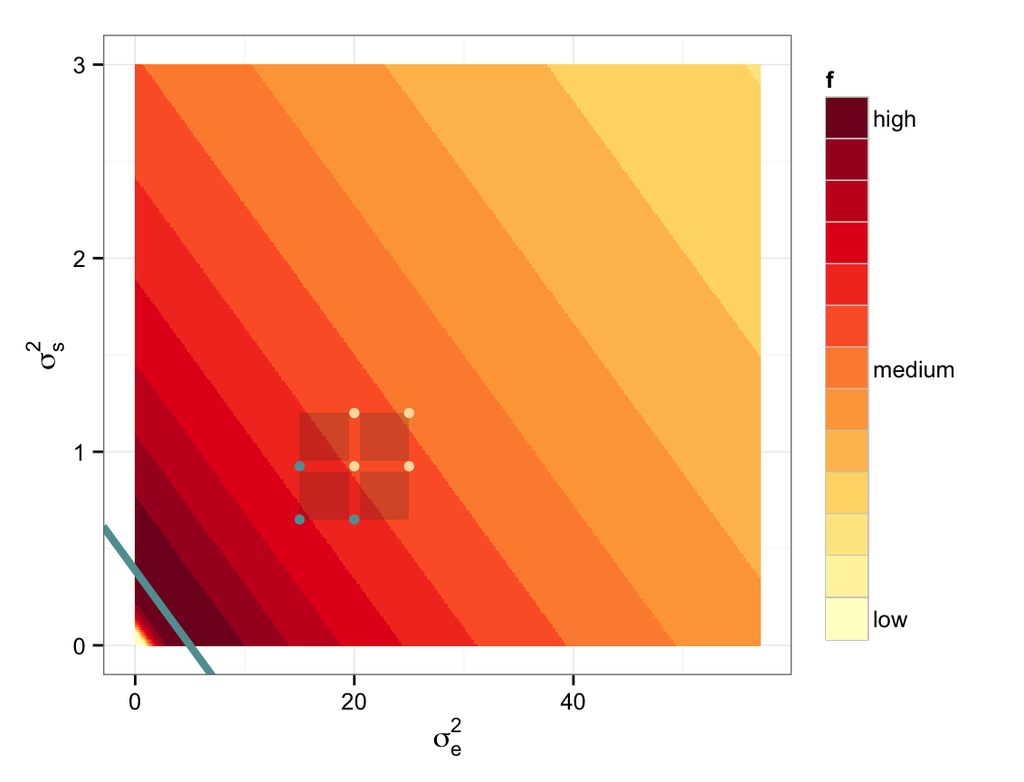

## Observations from one term

- Each term is maximized along a line in Q1.
- Slope < 0 and intercept > 0.
- Within \(b\) the top-right and bottom-left form the bounds.
  - above the line, \(\left(f(TR), f(BL)\right)\)
  - below the line, \(\left(f(BL), f(TR)\right)\)
  - straddle the line, \(\left(min(f(TR), f(BL)), f(line)\right)\)
- For narrower bounds, subdivide \(b\) (branch).

## Contribution of two terms

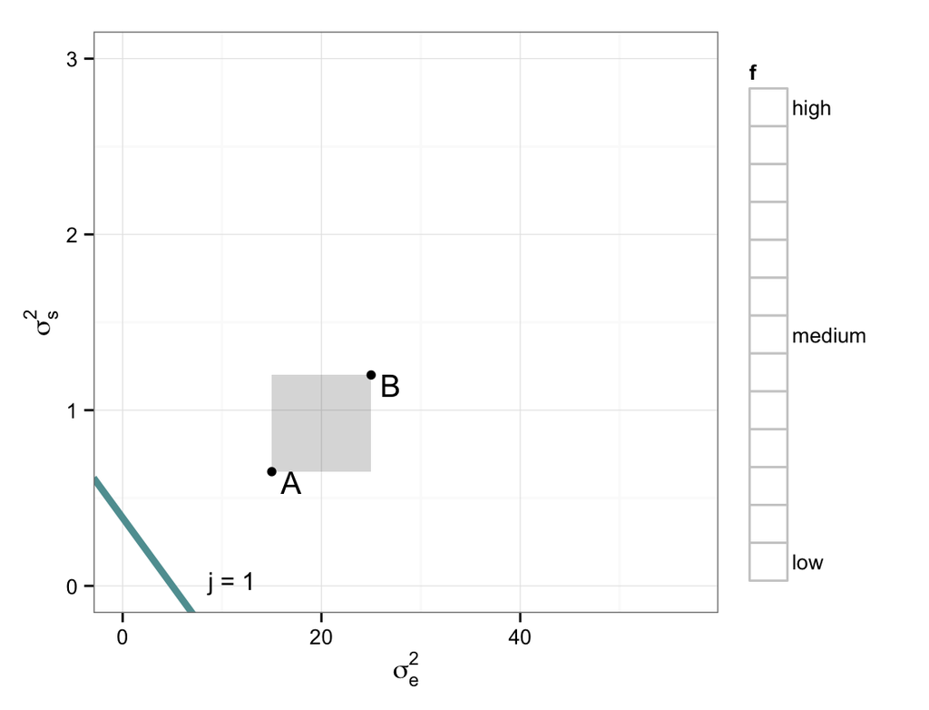

\[ j = 1; \quad \left(f_1(B), f_1(A) \right) \]

## Contribution of two terms

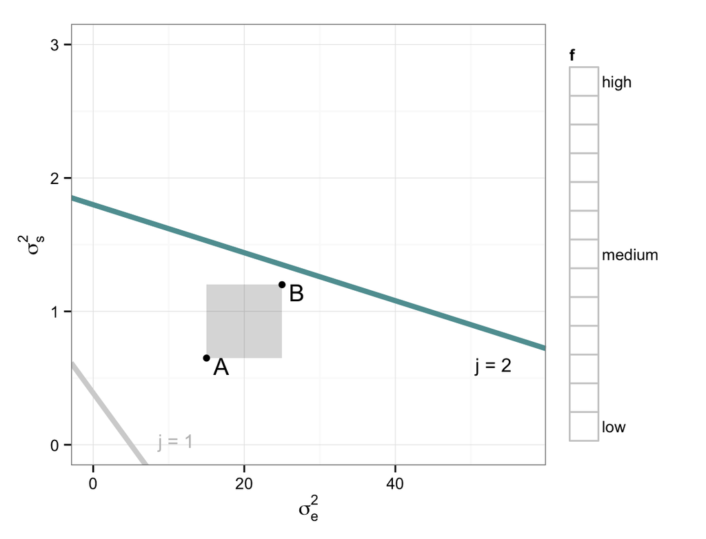

\[ j = 1; \quad \left(f_1(B), f_1(A) \right) \\ j = 2; \quad \left(f_2(A), f_2(B) \right) \]

## Contribution of two terms

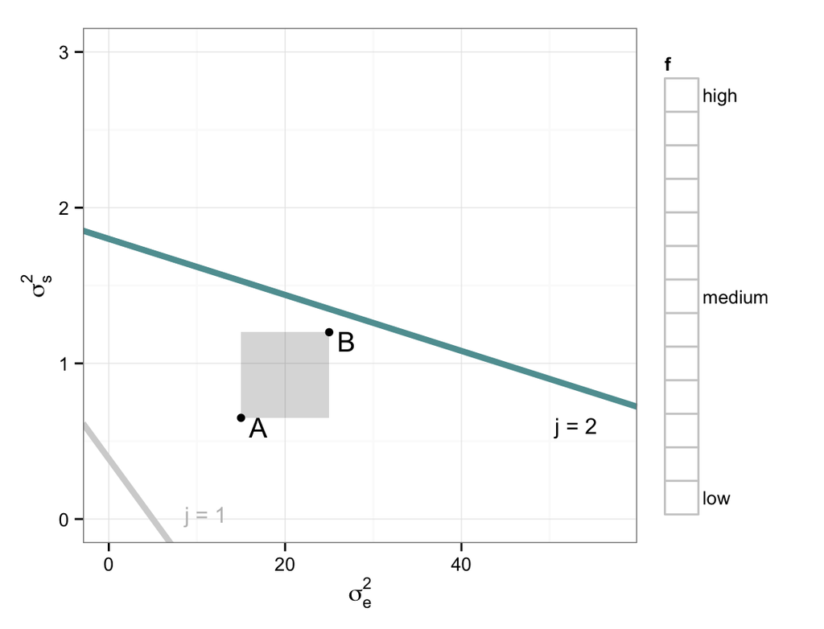

\[ \left.\begin{aligned} j &= 1; \quad \left(f_1(B), f_1(A) \right)\\ j &= 2; \quad \left(f_2(A), f_2(B) \right) \end{aligned} \right\} \qquad \underbrace{f_1(B) + f_2(A)}_{L^b}, \underbrace{f_1(A) + f_2(B)}_{U^b} \]

## Observations from two terms

Within box \(b\), the bounds on \(f\) can be formed by

\[ L^b \equiv \sum_j L^b_j \\ U^b \equiv \sum_j U^b_j \]

where each term in the sum is \(f_j(p)\) evaluated at the appropriate point \(p\).

## An algorithm

To evaluate \(f\) arbitrarily well everywhere within active box \(B\),

1. Specify \(\epsilon\).
2. With \(y, X, Z\) compute \(\{a_j, b_j, c_j, d_j\}\) for all \(j\).
3. For every active box \(b\)
- evaluate \(f_j(p)\) for all \(j\) to get \(L^b, U^b\)
- if \(U^b - L^b < \epsilon\), make \(b\) inactive
- else subdivide \(b\) into 4 active boxes and repeat (3).

## Unanswered questions

1. General Algorithm
   - establish worst-case runtime
   - more sensible branching
2. Algorithm on Likelihoods
   - explore more bounding methods!
3. Implementation
   - `data.table()`
   - bound inheritance